# Exercise 6:Insect Pests

Emily Simmonds

# Instructions:

This document contains information, questions, R code, and plots.

**Hints and reminders are bold**

Questions appear in blue.

**Needs to be completed and handed in by 11th March, 2022, 23:59**

# Rationale

This week you will be looking at how to use linear models when we have categorical explanatory variables. We will look at the techniques to use, practicing how to use them, and focus on interpreting results and how this is different to continuous explanatory variables.

# R hints and general help

## Definitions:

**Vector**: a sequence of data elements of the same basic type e.g. 1, 10, 3, 7, 4 or TRUE, FALSE, TRUE

# Resources:

- Background on Rothamsted and Fisher - why they are important in statistics (p8 The New Statistics with R)
- [Help on data types](https://qmbio.math.ntnu.no/theory/all-about-data/)
- Week 4 - t-test. [Module](https://www.math.ntnu.no/emner/ST2304/2021v/Week04/Lecture4Module.html)
- Week 5 - regression. [Module](https://www.math.ntnu.no/emner/ST2304/2021v/Week05/Regression_module.html)
- Week 7 - design matrix. [Module](https://www.math.ntnu.no/emner/ST2304/2021v/Week07/MultipleRegressionModule.html)
- Your brain - we will spend more time on this part of the exercise thinking through **why** we are doing things and what it shows rather than just running the analyses.

## Extras (try to complete without these, but if you get stuck use them)

- [How to read lm() output](https://www.math.ntnu.no/emner/ST2304/2020v/Week08/Reading_lm_output.pdf)
- [Reminder of confidence interval definition1](https://en.wikipedia.org/wiki/Confidence_interval)

## R this week:

Things to remember:

- `lm()` takes the arguments x, y, and data e.g. `lm(y ~ x, data = YOURDATA)` x and y here correspond to an explanatory variable (x) and a response (y)
- `plot()` and `abline()`
- `predict()`
- `confint()` and `coef()`
- `qqnorm()` and `qqline()`
- `summary(YourModel)$r.squared`

# The challenge: Did we have a solution to insect pests back in 1942?

This week your group are a team of scientists looking into how we can control insect pests on crops. You will look at the influence of insecticides on insects of crop plots in Ontario, Canada in 1942.

The data comes from a scientific paper from 1942 http://www.bio.umass.edu/biology/kunkel/pub/Biometry/Beale_InSpra-Biom1942.pdf, pretty old. You have columns of the:

- **biomass** (this was originally a count but we have altered it to be an indicator of biomass because we should do a different kind of model for counts - which we will cover in a few weeks) of the dead insects randomly sampled in the plot after the treatment.
- **spray**, which insecticide spray the plot was treated with (no one seems to know what these actually were - good lesson to always keep good notes!).

Here is a picture of an insect pest - the tomato hornworm *Manduca quinquemaculata* - in its most elegant form. (credit- wikipedia)

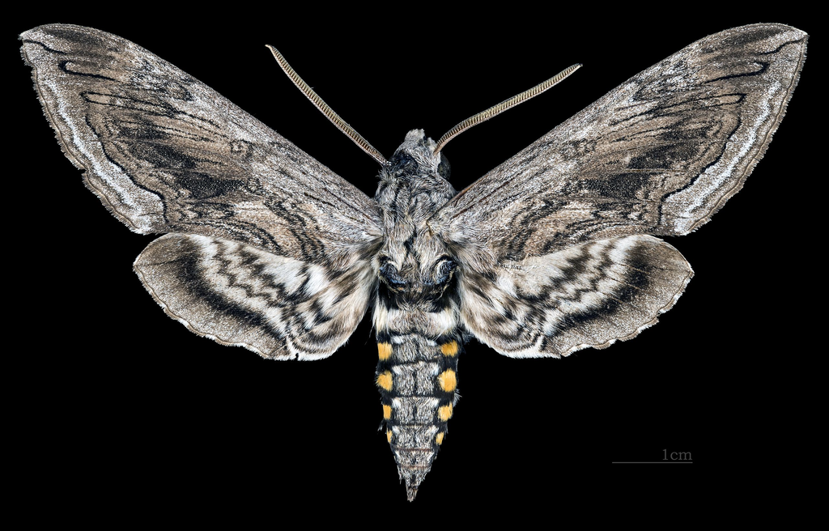

Insect picture

The experiment was run by taking several independent crop plots of nightshade *solanaceae* (tomatoes, peppers etc) and spraying them with one of six different insecticide sprays (again, we only know them as A,B,C,D,E,F). Insects were randomly sampled (dead ones) after the treatment.

The data cover 72 plots, each spray was applied on 12 plots.

Your job is to find out whether these sprays influence the amount of insects killed on a crop.

# Part A: Choosing a model

The data can be found at https://www.math.ntnu.no/emner/ST2304/2019v/Week8/InsectData.csv

The first step is to import the data and assign it to an object. You can use the whole web link above to import the data. It is a csv file with column names (header) included.

**One extra thing this week.** You will need to check the format of your data using the `str()` function. You want to column `biomass` to be numeric and `spray` to be a factor. It could be that spray originally comes in as `chr` which means character. If this happens, you will need to change the way it is stored in R using: `InsectData$spray <- as.factor(InsectData$spray)`. **This is good practice for when you use your own data**. Then you should ALWAYS check how it is stored in R before doing an analysis.

The next step, as always, is to **plot** our data. As we just have two columns we can use the `pairs()` function. (This won’t work if you miss the extra step to check the format of the data above.)

Take a look at the plot and think about the experimental design.

A1. **What** is the response variable and **what** is the explanatory variable here? **What** kind of data are each of these?

If you are unsure of what *kind* of data means. Take a look at the data types help at the top of this document.

You want to try and model this data. Given your answer to question A1:

A2. **What** would do you think we want to capture mathematically here? (Think about what kind of question you can ask or model you can use.)

**I’m not sure I understand this question.**

This question is asking you to start thinking about the whole modelling process, beginning with choosing the appropriate model for your data.

One way to do this, is to think about what you can find out or would want to ask based on your data. For example, if you collected data on temperature and plant height you might want to see if there is a relationship between temperature and height or ask how temperature influences plant height.

In that example you would be choosing to mathematically capture how much height changes with temperature i.e. a slope of a line, which would be a regression model. You can choose this because both variables are continuous. This would not be quite the same if one of them was categorical.

So, to choose a model you need to think about your **question of interest** and the **type of variables/data you have**.

**General hint: think about the kind of values we can get out of models e.g. we can characterise a relationship, estimate a difference between means, estimate a probability (these are all examples of models we have used), which is most appropriate here?**

A3. **write** question A2 as a question about biology.

# Part B: Estimate parameters

Hopefully you have suggested something for question A3 that can be achieved with a linear model i.e. `lm()`. If this is the case, we can run an `lm()` for our data. You should know how to do this by now. We want our treatment column (just the column name) as our X value and the response as our Y.

B1. **Run** an `lm()` for your question in A2/A3.

**We did not come up with a question.**

To come up with a model that will work for your data, you need to decide which of the variables in the data will be your **response (Y) variable** and what will be your **explanatory (X) variable**.

Think about which variable is most likely to influence the other. This is not always easy and it will depend a bit on what you want to find out. But there should be a direction that makes more sense. E.g. butterfly wing beats are unlikely to affect the amount of wind on a given day, but the amount of wind might affect how many beats a butterfly needs to stay flying.

**No, we still are not sure.**

With the insect data you have two variables (1) the biomass of dead insects and (2) the type of spray used on the crop. The amount of dead insects is unlikely to impact the spray, but we would expect the spray to have an influence on the amount of dead insects.

biomass = Y, spray = X

B2. **What** are the coefficient estimates you get from the `lm()` and **what** do they represent?

**Hint: think about the equation for a linear model in weeks 4 and 5.**

You already know that the biomass variable has been squareroot transformed to improve the fit of the linear model. But, we shouldn’t just take someone else’s word for this. We should also check ourselves. Even with categorical data, we still have pretty much the same assumptions for a linear model as we did for regression (but we no longer need a straight line!).

- Equal variance between each group
- Residuals are normally distributed at each X
- Residuals have zero mean
- Independence of data

B3. **Create** a residuals vs fitted and a Normal QQ plot for your model from B1. **What** do you think of the model fit? Remember to mention which assumptions are checked in each plot.

# Part C: The design matrix

**This section gives some more details on how to read a design matrix and what the different parts mean.**

The `lm()` function in R uses a design matrix to determine how to model the data you put in. It is a way of telling R how the different parts of the model fit together. You have seen these in the Lecture from Week 7. Luckily, R does this by default so usually you do not need to worry about the exact format of these matrices. But sometimes it can be a helpful way to think about model structure.

Here we will try and explain a bit more about these matrices, so that you can recognise the different elements that go in and how these relate to the linear model equation:

$$y_i = \alpha + \beta x_i + \epsilon_i$$

Also written as:

$$y_i = \beta_0 + \beta_1 x_i + \epsilon_i$$

We will explain this using a single example.

## The example:

I want to you to image a particular scenario for this rest of Part C. In the scenario, you have just designed and conducted an experiment. In this experiment, you wanted to look at how moon cycles affect werewolves. You designed an experiment where you measured the level of werewolf hormone in known werewolves. You did this at two different times “New moon” and “Full moon”.

[figure not shown]

Werefolf

In this example the response we have is hormone concentration and the explanatory variable is moon stage. Moon stage has two groups/levels, which are “New” and “Full”, so it is categorical. These can also be written as 0 = New and 1 = Full, this is called creating a **dummy variable**. A dummy variable is a numerical representation of our categorical variable.

## Back to the design matrix

Now you have an example to picture, we can look at the different parts of the design matrix.

The first part of the design matrix, $X$, to consider is the first column. This is indicated in black below. You can see that it is all 1s. This column represents the intercept of the model, $\alpha$ or $\beta_0$ in the linear model equation. We will explain more about why this is a 1 below.

In other words, this second column, and any others that come after, just contain the observed values of our explanatory/predictor variables. This is the $x$ part of the linear model equation above.

$$X = \left(\begin{matrix}
1 & \color{red}{0} \\\
1 & \color{red}{0} \\\
1 & \color{red}{1} \\\
1 & \color{red}{1} \\\
\end{matrix} \right)$$

So, with those two columns, you now have a design matrix for the example model! It contains your x values, we will call them covariate values here and a representation of the intercept.

In order to use this design matrix as part of the full model, you now need to specify some parameters that will be used to relate the $X$ matrix to your observed response values, the $y$ from the linear model equation.

To do this, we create a vector called $\beta$. It will contain all the parameter values we need ($\beta_0$ and $\beta_1$), so its length is two.

$$\beta = \left(\begin{matrix}
\beta_0 & \beta_1 \\\
\end{matrix} \right)$$

$Y$, your response data, is also a vector. It contains of all the values of $y$ that we observed.

## Linking it all together

Now that you have all of the elements of the model: the design matrix $X$, the observed responses $Y$, and an indication of parameter values $\beta$, you can combine them all to make your model and then use maximum likelihood estimation to find estimates of the parameter values within $\beta$.

To do this we use the following equation and some matrix multiplication.

Don’t worry, you don’t need to remember matrix multiplication, I will walk you through it here.

$$Y = X \beta + \epsilon$$

When you multiply a matrix by a vector (as we do with $X$ and $\beta$) the first column of the matrix gets multiplied by the first element of the vector. In this case, the first column of the matrix = the 1s that indicate the intercept and luckily, the first element of $\beta$ is the estimate of the value of the intercept. **Now we can see why we wanted 1s in our $X$ matrix!** This is because the intercept is a constant.

So, the next column of the design matrix, which is the values we measured for our covariates, then gets multiplied by the $\beta_1$ element of $\beta$. For our group 0, which was the New moon, this will = the intercept because $\beta_1$ is multiplied by 0. For our group 1, which was Full moon, this will = the mean hormone level when the moon is full and $\beta_1$ = the difference between the intercept (the mean hormone level when the moon is new) and the mean hormone level when the moon is full.

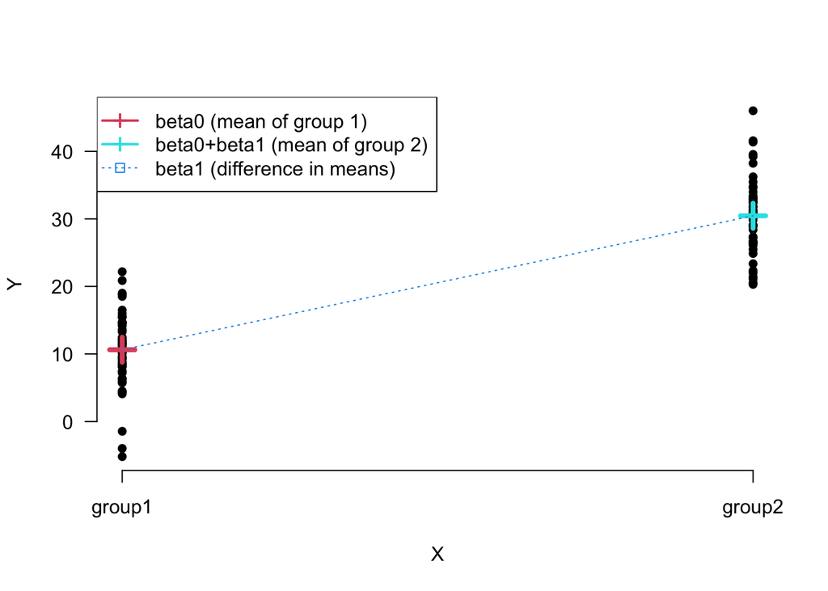

# Part D: Quantify uncertainty

Now that you have thought about what the numbers in your model output represent and checked your model fit, it is now time to add uncertainty.

D1. **Calculate** the confidence intervals for your model from B1.

**Hint.**

You can get R to calculate them for you using `confint()`

D2. **Describe** the output from `lm()`, include the confidence intervals here too and think about what they are the confidence intervals for. Describe the pattern the numbers show. You don’t need to interpret in a biological sense here, just explain what the numbers mean.

**Remember: confidence intervals represent the uncertainty around our estimate.**

D3. Do you think that the current output is the most helpful way to show the results of the `lm()`?

D4. **Why** is it important to quantify uncertainty in our parameter estimates?

# Part E: Interpret

The final step of any analysis is to interpret the results in context. In this case, you want to interpret what the results tell you about the question you wrote in A2/3.

E1. **Interpret** the output from the `lm()` in B1.

Now we want to add the biological meaning, not just the patterns of the numbers.

E2. **How** do these results help you answer your question from A2/3? (include the confidence intervals here too, can look at R squared as well).

Be specific here about relating back to the question. You might have mentioned some of this in E1 but now just relate it to the question from A2/3.

# Part F: Reflection

While we can get results here and draw conclusions. This data is quite old (more than 60 years old), and the data collection was not perfect. Also our aims might have changed. With invertebrate declines being more common, we might not want an insecticide that kills everything.

F1. If you were to re-design this experiment now in 2020 in Norway what would you do? **Write** a brief experimental design for this study.

You should include:

- What you want to find out (biological question).
- What treatments you would use. (Can add new ones you think were missed in 1942).
- Highlight one problem with the 1942 data and say how you would fix it.
- Which assumptions of a linear model do you need to consider in the experimental design phase? Say how you will do this.
- Maximum of 300 words, this should be short!

# Part G: Feedback

G1. How do you think this exercise went? What do you think your group did well, what are you less sure about? (2 examples of each)

G2. What do you think you improved from last week?

G3. Are there any concepts you are very unsure of?

G4. What would you like feedback on this week?